# Exploring FordgoBike dataset

## by Mohamed abdelrazik hanafy

## Investigation Overview

> In thins project im interesting in figuring out when and where are most trips and which subscribtion type is the favourite or makes lots of ride.

## Dataset Overview

> This data set includes information about individual rides made in a bike-sharing system covering the greater San Francisco Bay area. I will download data files foe each month from this [Link](https://www.google.com/url?q=https://www.fordgobike.com/system-data&sa=D&ust=1554486256012000) then i use data combing.ipynb to megre each file in single data frame then send it to a **csv** file which i read in this file

```python
# import all packages and set plots to be embedded inline
import numpy as np
import pandas as pd
import matplotlib.pyplot as plt
import seaborn as sns

%matplotlib inline

# suppress warnings from final output
import warnings
warnings.simplefilter("ignore")
```

```python
# load in the dataset into a pandas dataframe
df= pd.read_csv(r'C:\Users\Eng-mody\Desktop\Lyft bike data\data.csv')
```

> Note that the above cells have been set as "Skip"-type slides. That means that when the notebook is rendered as http slides, those cells won't show up.

```python
df['start_time'] = pd.to_datetime(df['start_time'])
df['start_month_char'] = df['start_time'].dt.month_name()
df['start_hour'] = df['start_time'].dt.hour
df['period_day'] = 'morning'
df['period_day'][(df['start_hour'] >= 12) & (df['start_hour'] <= 17)] = 'afternoon'
df['period_day'][(df['start_hour'] >= 18) & (df['start_hour'] <= 23)] = 'night'
df['start_weekday'] = df['start_time'].dt.day_name()
df['year']= df['start_time'].dt.year
# convert time period, month, and weekday into ordered categorical types
ordinal_var_dict = {'start_month_char': ['January','February','March','April','May','June','July','August','September','October','November','December'],
                    'period_day': ['morning', 'afternoon', 'night'],
                    'start_weekday': ['Monday', 'Tuesday', 'Wednesday', 'Thursday', 'Friday', 'Saturday', 'Sunday']}

for var in ordinal_var_dict:
    ordered_var = pd.api.types.CategoricalDtype(ordered = True,
                                                categories = ordinal_var_dict[var])
    df[var] = df[var].astype(ordered_var)
df.drop('Unnamed: 0',inplace = True,axis=1)
```

## (Visualization 1)

> In this visualization i will investigate the relationship between total number of rides and month of years. according to the graph rides decrease in march april may and june due to rain and we can look at this climate report for sanfrancisco over the year from [Here](https://www.usclimatedata.com/climate/san-francisco/california/united-states/usca0987)

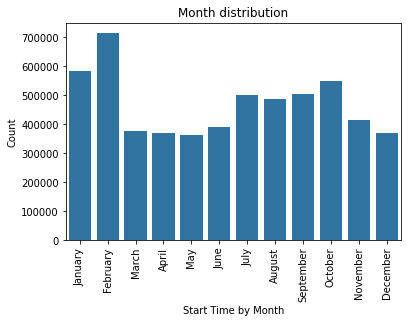

```python
# 1. Time by months
base_color = sns.color_palette()[0]
sns.countplot(data=df, x='start_month_char', color=base_color)
plt.xlabel('Start Time by Month')
plt.ylabel('Count')
plt.xticks(rotation=90)
plt.title('Month distribution');
```

## (Visualization 2)

> In the next visualization i look for number of rides for each day and its obvious that rides decreases on Weekends **(Saturday and Sunday)**

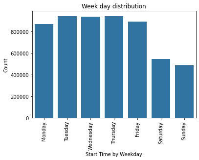

```python
# 1. distribution according to week day
base_color = sns.color_palette()[0]
sns.countplot(data=df, x='start_weekday', color=base_color)
plt.xlabel('Start Time by Weekday')
plt.ylabel('Count')
plt.xticks(rotation=90)
plt.title('Week day distribution');
```

## (Visualization 3)

> In the next visualization i look for number of rides during the day and its obvious that rides on moring and afternoon is more than at night due to high traffic for people going to work in moring and return to their home in afternoon.

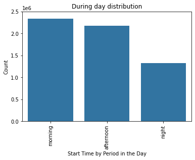

```python
# 1. Time by period in each day
base_color = sns.color_palette()[0]
sns.countplot(data=df, x='period_day', color=base_color)
plt.xlabel('Start Time by Period in the Day')
plt.ylabel('Count')
plt.ylim((0,2500000))
plt.xticks(rotation=90)
plt.title('During day distribution');
```

## (Visualization 4)

> In the next visualization i look for number of rides for each rental method and it's obvious that rent from app is more than clipper

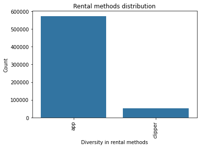

```python
base_color = sns.color_palette()[0]
sns.countplot(data=df, x='rental_access_method', color=base_color)
plt.xlabel('Diversity in rental methods')
plt.ylabel('Count')
plt.xticks(rotation=90)
plt.title('Rental methods distribution');
```

## (Visualization 5)

> In the next visualization i look for number of rides per subscribers and regular customer and i figure out that riders who make high number of rides are subscribers this due to **LYFT pricing ploicy you can learn more abour pricing from [Here](https://account.baywheels.com/access-plans?lyft-branded)**

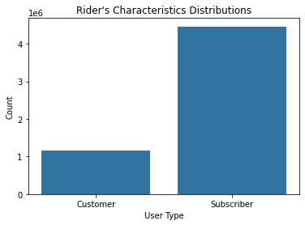

```python
# Rider's characteristics: the distributions of user type
default_color = sns.color_palette()[0]
sns.countplot(data = df, x = 'user_type', color = default_color)
plt.xlabel('User Type')
plt.ylabel('Count')

plt.title('Rider\'s Characteristics Distributions');
```

## (Visualization 6)

> In the next visualization i look for the distribution of ride's duration

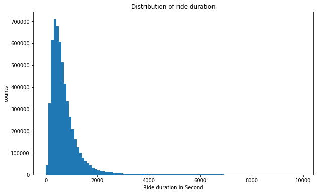

```python
bins = np.arange(0,10000, 100)
plt.figure(figsize=(10,6))
plt.hist(x= df['duration_sec'],bins=bins)
plt.xlabel("Ride duration in Second")
plt.ylabel("counts")
plt.title("Distribution of ride duration")
```

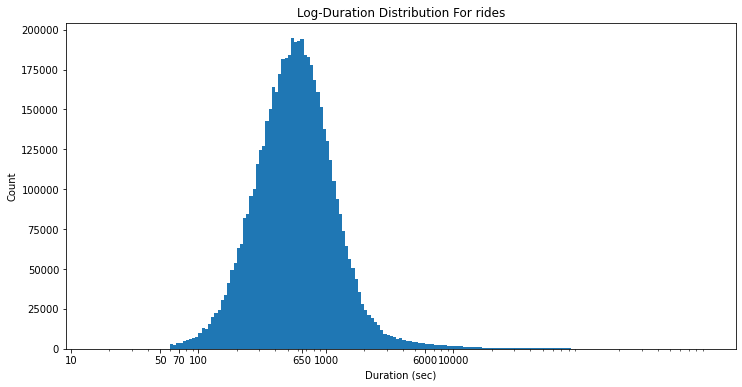

```python
# there's a long tail in the distribution, so let's put it on a log scale instead
log_binsize = 0.025
bins = 10 ** np.arange(1.2, np.log10(df['duration_sec'].max())+log_binsize, log_binsize)

plt.figure(figsize=[12, 6])
plt.hist(data = df, x = 'duration_sec', bins = bins)
plt.xscale('log')
plt.xticks([10,50,70,100,650,1000,6000,10000], [10,50,70,100,650,1000,6000,10000])
plt.xlabel('Duration (sec)')
plt.ylabel('Count')
plt.title('Log-Duration Distribution For rides');
```

```python
top_start_station = list(df['start_station_name'].value_counts()[:10].index)
top_end_station=list(df['end_station_name'].value_counts()[:10].index)
df2=df[df['start_station_name'].isin(top_start_station)]
order1= df2["start_station_name"].value_counts().index.values
df3=df[df['end_station_name'].isin(top_start_station)]
order2= df3["end_station_name"].value_counts().index.values
```

## (Visualization 7)

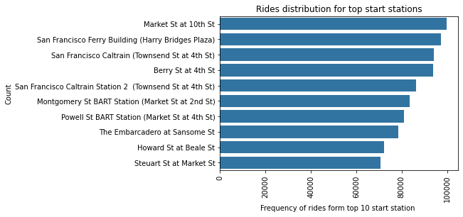

```python
base_color = sns.color_palette()[0]
sns.countplot(data=df2, y='start_station_name', color=base_color,order=order1)
plt.xlabel("Frequency of rides form top 10 start station ")
plt.ylabel('Count')
plt.xticks(rotation=90)
plt.title('Rides distribution for top start stations');
```

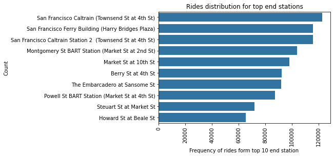

```python
base_color = sns.color_palette()[0]
sns.countplot(data=df3, y='end_station_name', color=base_color,order=order2)
plt.xlabel("Frequency of rides form top 10 end station ")
plt.ylabel('Count')
plt.xticks(rotation=90)
plt.title('Rides distribution for top end stations');
```